# Assessing EVI enhancement in 30 m data, Boston AOI

Drew Trlica

2018-02-28

Landsat 7 imagery from the Analaysis Ready Data collection was combined for all July acquisitions 2010-2012 to produce a summer EVI map for the area of interest (AOI), roughly the area between Interstate 495 and downtown Boston, Massachusetts. This data was combined with aggregated high-resolution data on impervious surface area (ISA) fraction and land-use/land-cover (LULC) classification provided by MassGIS.

Following the method of Zhao et al. (2016), we determined end-member EVI values for fully vegetated and fully impervious pixels, then calculated a “zero-effect” model for EVI as a linear function of impervious fraction. This zero-effect model was compared to the binned average EVI vs impervious fraction to determine observed deviance from the linear model. This approach follows the analysis of Zhao et al. (2016) in evaluating the relative loss of EVI as a function of increasing “urbanization intensity”. Pixels were masked to the AOI and filtered to remove water pixels.

#### Figure 1: EVI enhancement binned by ISA

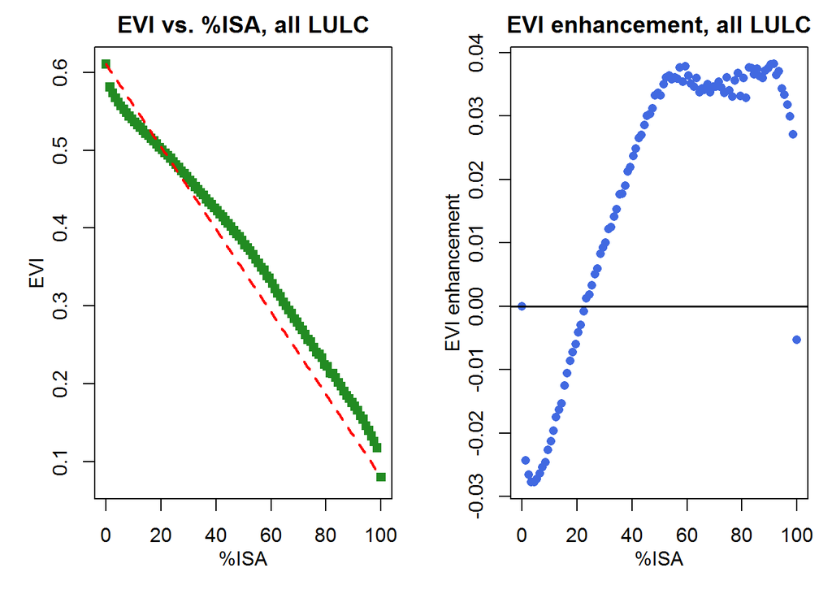

Figure 1 shows that median EVI is reduced with increasing sub-pixel ISA fraction across the range of ISA. Below 20-30% ISA, EVI is reduced more for each unit increment of impervious area than predicted by the linear zero-effect model. Above 20-30% ISA, EVI diminishes more slowly than predicted for each unit increase in ISA (i.e. an area loss of vegetation to ISA does not result in a corresponding decrease in whole-pixel EVI). This “enhancement effect” increases up to ISA of about 50%, and from 50-90% ISA EVI stably remains about 0.04 units higher than predicted by the zero-effect model.

When disaggregated to pixel populations of the same LULC class, this phenomenon of differential effect on EVI changes according to LULC. The difference in EVI effect may relate to vegetation stature.

#### Figure 2: EVI vs. ISA for selected LULC-classed pixels, classes >= 1% AOI (>86k pixels), 95% cumulative area of AOI.

##### Figure 2a: Forest-type classes

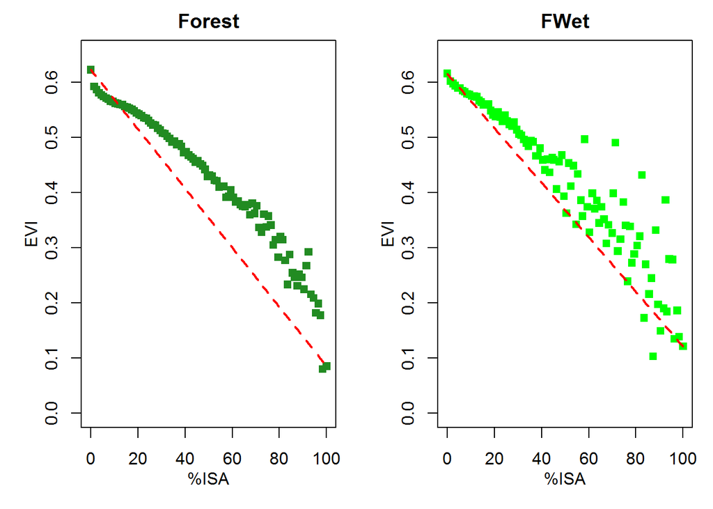

##### Figure 2b: Low-stature vegetation classes

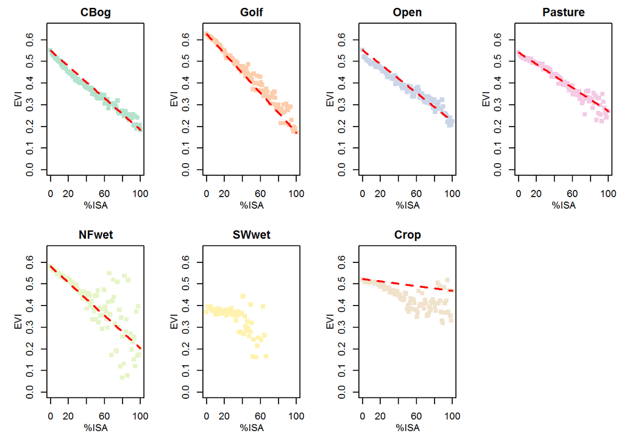

In these more “naturalistic” LULC classes, tree-dominated classes (Fig 2a) show EVI enhancement in pixels at the high end of the ISA scale, while classes presumably dominated by low-stature vegetation (Fig 2b) show an decline in EVI close to the predicted zero-effect line or somewhat below it (i.e. loss of vegetation area results in greater than predicted decline in EVI).

Contrast to LULC classes presumably under stronger human influence:

##### Figure 2c: Residential classes by density

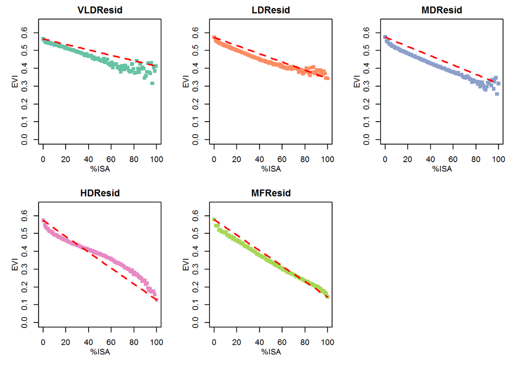

In residential classes pixels, overall EVI decline across the ISA range is greater with increasing density, near to the whole-area range in the highest densities. Lower-density (VLD, LD, MD) residential classes show an EVI deficit in the lower ISA ranges with a slight increase near the upper end of the range, while HD and MF residential classes show a reversal to EVI enhancement at very high ISA. These results imply that while lower-density residential pixels show comparatively high reduction of EVI per increment ISA (while maintaining overall higher EVI), in the higher end of ISA in the most dense residential categories EVI is reduced less per increment ISA.

Other developed classes show comparable patterns in EVI vs. ISA:

##### Figure 2d: Other developed LULC classes

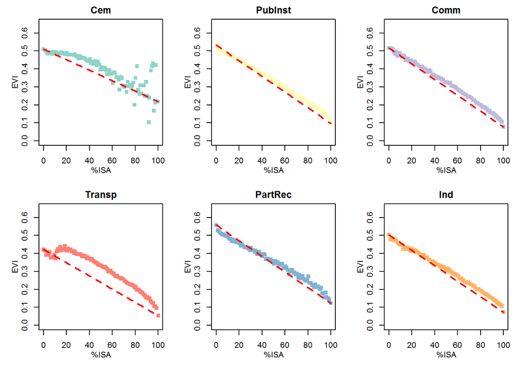

These developed classes show less severe EVI reduction per unit increase in ISA (EVI “enhancement”) per area increment of impervious cover, particularly at the upper end of the ISA range.

The total EVI vs. ISA curve for the study area is a composite of all LULC classes, of which the previous graphs cover 96% of the study are (39% of which is “Forest”). A potential explanation for the behavior of this relationship may be that many of the classically “urban” LULC classes tend to be dominated by larger stature vegetation (trees). In these classes, as in forest/forested wetland, increase in ISA from 0 causes a steady or even somewhat heightened decline in EVI (possibly a result of land clearance and loss of canopy near structures or pavement). As development intensity reaches the higher range of ISA increasing impervious fraction has a diminishing effect on reducing EVI, potentially because ISA increasingly appears *beneath* the canopy (i.e. nearly completely “developed” pixels can still show a reasonably large vegetated surface). A similar explanation could be proffered for the higher density residential LULC classes. In contrast, LULC classes dominated by low-stature vegetation (e.g. cranberry bogs, pastures, golf courses) show a linear or greater decline in EVI with increasing ISA, as each area increment of impervious cover results in at least the same loss in satellite-visible vegetation cover, or possibly greater loss due to clearance of surrounding vegetation. (Note that analysis of 1m data for Boston show a slight but variable decrease in NDVI in low-stature “grass” compared to higher-stature “canopy” vegetated pixels – a tendency for replacement of “canopy” by “grass” in increasingly developed pixels would therefore result in a lower than expected decline in EVI). This model may apply to the lower-density residential classes (development and clearance of low-stature vegetation), or these classes may represent a comparatively large loss of tree-stature vegetation with increasing density of structure and pavement (i.e. land clearance) up to the highest ISA classes in which impervious cover appears increasingly beneath the remaining vegetation canopy.

These results highlight an important empirical fact: Simple surface metrics like fractional impervious cover (or even fractional “developed” cover, as in Zhao et al. [2016]) may not provide a straightforward metric of the expected radiative properties of highly developed or human-modified landscapes.